# projeto_covid

Lucas Vinicius

2022-12-22

# Analisando os dados da covid 19 no Brasil

Dados encontrados em https://brasil.io/ Nesse dataset queremos responder 4 perguntas.

**1.** Qual o estado teve maior numero de mortes por covid?

**2.** Qual cidade em media houve mais casos?

**3.** Media de casos ao longo do tempo na cidade com mais mortos?

**4.** Soma de mortos ao longo do tempo no DF?

**Ferramentas utilizadas:** R,SQL,Tidyverse, readr e Google data studio.

```r
# importando bibliotecas
library(tidyverse)
library(readr)
library(sqldf)
# importando dados
df <- read_csv("caso_full.csv")
# visualizando as primeiras linha do dataset
head(df)
```

```
## # A tibble: 6 × 18
##   city       city_i…¹ date       epide…² estim…³ estim…⁴ is_last is_re…⁵ last_…⁶
##   <chr>         <dbl> <date>       <dbl>   <dbl>   <dbl> <lgl>   <lgl>     <dbl>
## 1 Rio Branco  1200401 2020-03-17  202012  413418  407319 FALSE   FALSE         3
## 2 <NA>             12 2020-03-17  202012  894470  881935 FALSE   FALSE         3
## 3 Rio Branco  1200401 2020-03-18  202012  413418  407319 FALSE   FALSE         3
## 4 <NA>             12 2020-03-18  202012  894470  881935 FALSE   FALSE         3
## 5 Rio Branco  1200401 2020-03-19  202012  413418  407319 FALSE   FALSE         4
## 6 <NA>             12 2020-03-19  202012  894470  881935 FALSE   FALSE         4
## # … with 9 more variables: last_available_confirmed_per_100k_inhabitants <dbl>,
## #   last_available_date <date>, last_available_death_rate <dbl>,
## #   last_available_deaths <dbl>, order_for_place <dbl>, place_type <chr>,
## #   state <chr>, new_confirmed <dbl>, new_deaths <dbl>, and abbreviated
## #   variable names ¹city_ibge_code, ²epidemiological_week,
## #   ³estimated_population, ⁴estimated_population_2019, ⁵is_repeated,
## #   ⁶last_available_confirmed
```

```r
# Descobrindo quantas colunas e linhas o dataset possui
dim(df)
```

```
## [1] 3853648      18
```

```r
# mostrando todas colunas do df
names(df)
```

```
##  [1] "city"
##  [2] "city_ibge_code"
##  [3] "date"
##  [4] "epidemiological_week"
##  [5] "estimated_population"
##  [6] "estimated_population_2019"
##  [7] "is_last"
##  [8] "is_repeated"
##  [9] "last_available_confirmed"
## [10] "last_available_confirmed_per_100k_inhabitants"
## [11] "last_available_date"
## [12] "last_available_death_rate"
## [13] "last_available_deaths"
## [14] "order_for_place"
## [15] "place_type"
## [16] "state"
## [17] "new_confirmed"
## [18] "new_deaths"
```

Esse dataframe possui 3.853,648 linhas e 18 colunas

```r
# Verificando quantos estados o df possue
sqldf(
  "SELECT
    COUNT(DISTINCT(state)) AS total_estados
  FROM
    df"
)
```

```
##   total_estados
## 1            27
```

## Limpando os dados

Antes de usarmos o SQL para responder as 4 perguntas, vamos usar o R para limpar os dados. Primeiros vamos checar os tipos de variaveis, depois vamos remover os valores nulos e por ultimo iremos remover os valores duplicados

**Checando tipos de variaveis**

```r
# Transformando a variavel place_type de string para factor (variavel categorica nominal)
df$place_type <- as.factor(df$place_type)
class(df$place_type)
```

```
## [1] "factor"
```

```r
unique(df$place_type)
```

```
## [1] city  state
## Levels: city state
```

```r
# Tipos de variaveis
glimpse(df)
```

```
## Rows: 3,853,648
## Columns: 18
## $ city                                          <chr> "Rio Branco", NA, "Rio B…
## $ city_ibge_code                                <dbl> 1200401, 12, 1200401, 12…
## $ date                                          <date> 2020-03-17, 2020-03-17,…
## $ epidemiological_week                          <dbl> 202012, 202012, 202012, …
## $ estimated_population                          <dbl> 413418, 894470, 413418, …
## $ estimated_population_2019                     <dbl> 407319, 881935, 407319, …
## $ is_last                                       <lgl> FALSE, FALSE, FALSE, FAL…
## $ is_repeated                                   <lgl> FALSE, FALSE, FALSE, FAL…
## $ last_available_confirmed                      <dbl> 3, 3, 3, 3, 4, 4, 7, 7, …
## $ last_available_confirmed_per_100k_inhabitants <dbl> 0.72566, 0.33539, 0.7256…
## $ last_available_date                           <date> 2020-03-17, 2020-03-17,…
## $ last_available_death_rate                     <dbl> 0, 0, 0, 0, 0, 0, 0, 0, …
## $ last_available_deaths                         <dbl> 0, 0, 0, 0, 0, 0, 0, 0, …
## $ order_for_place                               <dbl> 1, 1, 2, 2, 3, 3, 4, 4, …
## $ place_type                                    <fct> city, state, city, state…
## $ state                                         <chr> "AC", "AC", "AC", "AC", …
## $ new_confirmed                                 <dbl> 3, 3, 0, 0, 1, 1, 3, 3, …
## $ new_deaths                                    <dbl> 0, 0, 0, 0, 0, 0, 0, 0, …
```

**Valores faltantes** Somente removemos os valores faltantes se não tiver um grande efeito nos dados, no meu caso criei uma nova variavel contendo o df sem os valores NA e podemos perceber que foram limpos 49.279 registros, o que pode afetar bastante o nosso dataset

```r
df_limpo <- df |>
  select(everything()) |>
  na.omit() # remove todos os valores faltantes

dim(df) - dim(df_limpo)
```

```
## [1] 49279     0
```

```r
rm(df_limpo)
```

**Valores duplicados**

```r
# Identificando valores duplicados
# Para selecionarmos variaveis duplicadas utilizamos a função duplicated()
# Queremos apenas os valores que não estão duplicados
#df <- df[!duplicated(df),]
```

## Usando SQL

- Limitei para 10 linhas as saidas de cada query e coloquei e ordem decrescente.

**1.** Qual o estado teve o maior numero de mortes por covid?

```r
# criando query

sqldf(
  "SELECT
    DISTINCT(state) as estados,
    SUM(new_deaths) as mortes
  FROM
    df
  GROUP BY
    (estados)
  ORDER BY
    mortes DESC
  LIMIT 10;
  "
)
```

```
##    estados mortes
## 1       SP 321479
## 2       RJ 139117
## 3       MG 114929
## 4       PR  83253
## 5       RS  77935
## 6       BA  56978
## 7       CE  50847
## 8       GO  50716
## 9       SC  42773
## 10      PE  41301
```

**2.** Qual cidade em media houve mais casos?

```r
sqldf(
  "SELECT
    DISTINCT(city) AS cidades,
    ROUND(AVG(new_confirmed),2) AS casos
  FROM
    df
  GROUP BY
    cidades
  ORDER BY
    casos DESC
  LIMIT 10;
  "
)
```

```
##           cidades   casos
## 1            <NA> 1483.66
## 2       São Paulo 1281.12
## 3        Brasília  796.10
## 4  Rio de Janeiro  644.19
## 5  Belo Horizonte  375.16
## 6       Fortaleza  345.61
## 7    Porto Alegre  328.77
## 8        Salvador  320.06
## 9        Curitiba  293.21
## 10        Goiânia  285.45
```

**3.** Media de casos ao longo do tempo na cidade com mais mortos

```r
sqldf(
  "
  SELECT
    DISTINCT(city) AS cidade,
    last_available_date,
    ROUND(AVG(new_confirmed) OVER (PARTITION BY city ORDER BY date),2) AS media
  FROM
    df
  WHERE
    city  = 'São Paulo'
  ORDER BY
    media DESC
  LIMIT 10;
  "
)
```

```
##       cidade last_available_date   media
## 1  São Paulo          2021-07-09 1742.73
## 2  São Paulo          2021-07-03 1742.19
## 3  São Paulo          2021-07-08 1741.23
## 4  São Paulo          2021-06-26 1740.77
## 5  São Paulo          2021-07-10 1740.68
## 6  São Paulo          2021-07-02 1740.35
## 7  São Paulo          2021-07-07 1740.25
## 8  São Paulo          2021-07-04 1740.10
## 9  São Paulo          2021-06-27 1739.45
## 10 São Paulo          2021-07-06 1739.36
```

**4.** Soma de mortos ao longo do tempo no DF?

```r
sqldf(
  "
  SELECT
    DISTINCT(city) AS estado,
    last_available_date,
    SUM(new_deaths) OVER (PARTITION BY city ORDER BY date) AS mortos
  FROM
    df
  WHERE
    city  = 'Brasília'
  ORDER BY
    mortos DESC
  LIMIT 10;
  "

)
```

```
##      estado last_available_date mortos
## 1  Brasília          2022-02-18  10363
## 2  Brasília          2022-02-17  10347
## 3  Brasília          2022-02-16  10334
## 4  Brasília          2022-02-15  10326
## 5  Brasília          2022-02-14  10318
## 6  Brasília          2022-02-11  10303
## 7  Brasília          2022-02-10  10289
## 8  Brasília          2022-02-09  10280
## 9  Brasília          2022-02-08  10270
## 10 Brasília          2022-02-07  10260
```

## Plotando a query no Google data studio

Antes de criarmos um dashboard no data studio, precisamos salvar essa query como um csv. Eu escolhi a pergunta 2 para plotar.

```r
# query
plot <- sqldf(
  "SELECT
    DISTINCT(city) AS cidades,
    ROUND(AVG(new_confirmed),2) AS casos
  FROM
    df
  GROUP BY
    cidades
  ORDER BY
    casos DESC
  LIMIT 10;
  "
)

# Salvando em csv
write_csv(plot, "/home/lucasv/Downloads/plot.csv")
```

Depois de subir o csv para o data studio e configurar dashboard basico, esse foi o resultado:

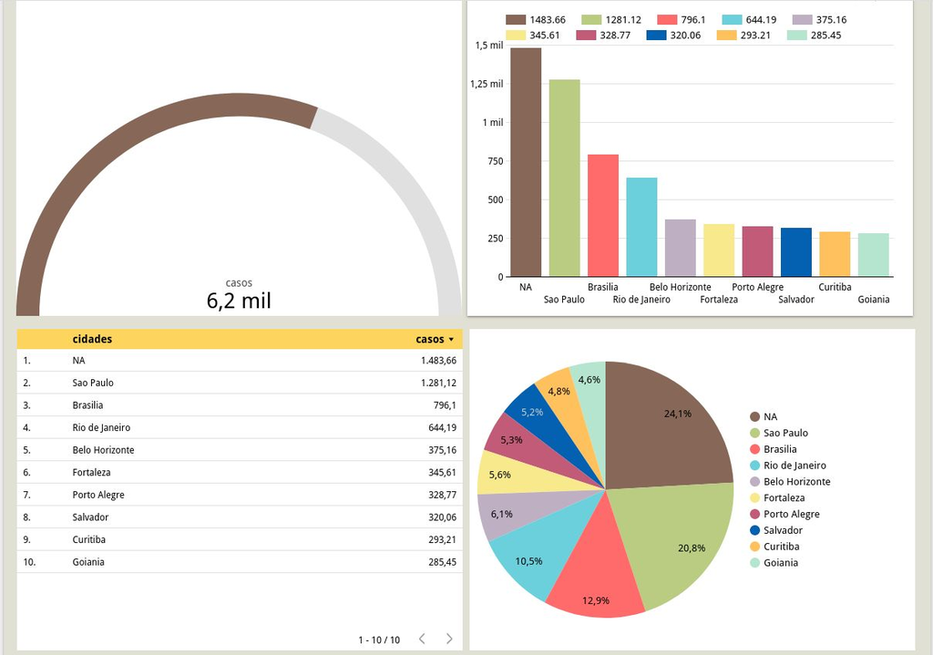

**link para acessar o dashboard** https://datastudio.google.com/reporting/9f788b3f-18a0-47fd-8ab4-ba67e2a5f8a7